# Flurex Compositional Analysis

## 4.4 CONCLUSION

No specific genera were found to have significant difference in abundance between the control group and the PFOS exposed group. On family level, 14 families from the Actinobacteria, Firmicutes and Proteobacteria phyla showed significant PFOS-driven difference in abundance. We focus mainly on Genus level on the paper, hence this figure is not included.

## 4.5 FECES DAY 8 - WITH VANCOMYCIN

### 4.5.1 GENUS

#### 4.5.1.1 RUN DAtest

```r
params <- readRDS("R_objects/comp_params.RDS")

LVL <- "Genus"
MTRL <- "Feces"
DAY <- "d8"
VAN <- "van"
PDI <- "treatment"
SUBNAME <- "Feces_d8"
load(paste0("R_objects/Agglomerated_",SUBNAME,".RData"))

# Create sub-folder
  if (!file.exists(paste0("plots/difabu/",SUBNAME))) dir.create(file.path(getwd(), paste0("plots/difabu/",SUBNAME)))

# Filter samples (if needed)
phy.ge <- subset_samples(phy.ge, material == MTRL & day %in% DAY & van == VAN)

# Filter data
filt <- preDA(data = phy.ge, min.reads = 20, min.samples = 4)
```

```
## 125 features grouped as 'Others' in the output
```

```r
# Run the selected analysis
filt.DA <- DA.tta(filt, predictor = PDI)

# Evaluate the plot and summary table
table(filt.DA$pval.adj < 0.05)
```

```
##
## FALSE  TRUE
##    47     1
```

```r
filt.p5 <- filt.DA[filt.DA$pval.adj < 0.05,]
write.csv(filt.p5,paste0("plots/difabu/",SUBNAME,"/stats_",MTRL,"_",DAY,"_",VAN,"_",PDI,"_",LVL,".csv"))

# Create a subset of the samples
filt.ra <- transform_sample_counts(filt, function(x) x/sum(x)*100)
DA.sig <- prune_taxa(filt.DA$Feature[filt.DA$pval.adj < 0.05], x = filt.ra)

if(exists("DA.sig")){
  # melt the data
  DAm <- psmelt(DA.sig)

  # Create plot
  pseudocount <- min(DAm$Abundance[DAm$Abundance != 0])
  p.dif <- ggplot(DAm, aes(x = Genus, y = Abundance+pseudocount, fill = fct_rev(treatment))) + geom_boxplot() + scale_y_log10() + coord_flip() + scale_fill_manual(values = params$COL, breaks=c("CTRL","PFOS","VAN","VAN+PFOS")) + facet_grid(Phylum ~ . , scales = "free_y", space = "free") + theme_bw() + labs(fill = "Treatment")
  p.dT <- p.dif + ggtitle(paste0("Differential abundance on ",LVL," level for ",MTRL," ",DAY," VAN: ",VAN))
  p.dT

  suppressMessages(ggsave(paste0("plots/difabu/",SUBNAME,"/diffplot_",SUBNAME,"_",VAN,"_",PDI,"_",LVL,".pdf"), p.dif, device = "pdf", units = "mm", width = 350, height = 200, dpi = 300))
  suppressMessages(ggsave(paste0("plots/difabu/",SUBNAME,"/diffplot_",SUBNAME,"_",VAN,"_",PDI,"_",LVL,".png"), p.dif, device = "png", units = "mm", width = 350, height = 200, dpi = 300))
} else cat("No significantly different taxa identified after adjustment for multiple testing")
# clear the environment and release memory
rm(list = ls(all.names = TRUE))
invisible(gc())
```

[output not shown]

### 4.5.2 FAMILY

#### 4.5.2.1 RUN DAtest

```r
params <- readRDS("R_objects/comp_params.RDS")

LVL <- "Family"
MTRL <- "Feces"
DAY <- "d8"
VAN <- "van"
PDI <- "treatment"
SUBNAME <- "Feces_d8"
load(paste0("R_objects/Agglomerated_",SUBNAME,".RData"))

# Create sub-folder
  if (!file.exists(paste0("plots/difabu/",SUBNAME))) dir.create(file.path(getwd(), paste0("plots/difabu/",SUBNAME)))

# Filter samples (if needed)
phy.fa <- subset_samples(phy.fa, material == MTRL & day %in% DAY & van == VAN)

# Filter data
filt <- preDA(data = phy.fa, min.reads = 20, min.samples = 4)
```

```
## 49 features grouped as 'Others' in the output
```

```r
# Run the selected analysis
filt.DA <- DA.tta(filt, predictor = PDI)

# Evaluate the plot and summary table
table(filt.DA$pval.adj < 0.05)
```

```
##
## FALSE
##    31
```

```r
filt.p5 <- filt.DA[filt.DA$pval.adj < 0.05,]
write.csv(filt.p5,paste0("plots/difabu/",SUBNAME,"/stats_",MTRL,"_",DAY,"_",VAN,"_",PDI,"_",LVL,".csv"))

# Create a subset of the samples
filt.ra <- transform_sample_counts(filt, function(x) x/sum(x)*100)
DA.sig <- prune_taxa(filt.DA$Feature[filt.DA$pval.adj < 0.05], x = filt.ra)
```

```
## Error in validObject(.Object): invalid class "otu_table" object:
##  OTU abundance data must have non-zero dimensions.
```

```r
if(exists("DA.sig")){
  # melt the data
  DAm <- psmelt(DA.sig)

  # Create plot
  pseudocount <- min(DAm$Abundance[DAm$Abundance != 0])
  p.dif <- ggplot(DAm, aes(x = Genus, y = Abundance+pseudocount, fill = fct_rev(treatment))) + geom_boxplot() + scale_y_log10() + coord_flip() + scale_fill_manual(values = params$COL, breaks=c("CTRL","PFOS","VAN","VAN+PFOS")) + facet_grid(Phylum ~ . , scales = "free_y", space = "free") + theme_bw() + labs(fill = "Treatment")
  p.dT <- p.dif + ggtitle(paste0("Differential abundance on ",LVL," level for ",MTRL," ",DAY," VAN: ",VAN))
  p.dT

  suppressMessages(ggsave(paste0("plots/difabu/",SUBNAME,"/diffplot_",SUBNAME,"_",VAN,"_",PDI,"_",LVL,".pdf"), p.dif, device = "pdf", units = "mm", width = 350, height = 200, dpi = 300))
  suppressMessages(ggsave(paste0("plots/difabu/",SUBNAME,"/diffplot_",SUBNAME,"_",VAN,"_",PDI,"_",LVL,".png"), p.dif, device = "png", units = "mm", width = 350, height = 200, dpi = 300))
} else cat("No significantly different taxa identified after adjustment for multiple testing")
```

```
## No significantly different taxa identified after adjustment for multiple testing
```

```r
# clear the environment and release memory
rm(list = ls(all.names = TRUE))
invisible(gc())
```

## 4.6 CONCLUSION

One specific genera, unclassified “Family_Enterobacteriaceae”, was found to have significant PFOS-driven difference in abundance between the two vancomycin-treated groups. On family level, no significant PFOS-driven difference in abundance was found. We investigate the Enterobacteriaceae in depts below.

## 4.7 ENTEROBACTERIACEAE > GENERA

Significant difference in abundance was found for unclassified genera “Family_Enterobacteriaceae” above. Here we investigate and plot all genera present on day 8 in the family “Enterobacteriaceae”.

```r
# Collected figures for Families showing significant differences
params <- readRDS("R_objects/comp_params.RDS")
LVL <- "Genus"
# MTRL <- "Feces"
DAY <- "d8"
VAN <- "van"
SUBNAME <- "Feces_d8"
PDI <- "treatment"
TX <- "Enterobacteriaceae"
#c("Erysipelotrichaceae","Enterobacteriaceae")

LVL <- "Genus"
# Create sub-folder
if (!file.exists(paste0("plots/difabu/",SUBNAME))) dir.create(file.path(getwd(), paste0("plots/difabu/",SUBNAME)))
# Load agglomorated subset
load(paste0("R_objects/Agglomerated_",SUBNAME,".RData"))
# Filter samples based on variables given
#phy.ge <- subset_samples(phy.ge, material == MTRL & day %in% DAY)
# Filter data
filt <- preDA(data = phy.ge, min.reads = 20, min.samples = 4)
```

```
## 80 features grouped as 'Others' in the output
```

```r
# Run tha selected analysis TTA
filt.DA <- DA.tta(filt, predictor = PDI)
# Create a subset of the samples
filt.ra <- transform_sample_counts(filt, function(x) x/sum(x)*100)
filt.t <- subset_taxa(filt.ra, Family == TX)
# Melt the data
t.melt <- psmelt(filt.t)
# Create pseudocounts
pseudocount <- min(t.melt$Abundance[t.melt$Abundance != 0])
# Sort samples to phylogenetic levels (alphabetically)
t.sorted <- t.melt %>% select(Phylum:Genus) %>% arrange(Phylum, Class, Order, Family, Genus)
genus.sorted <- as.character(unique(t.sorted$Genus))
t.melt$genus_new <- factor(t.melt$Genus, levels = genus.sorted)

levels(t.melt$genus_new) %>% head
```

```
## [1] "Escherichia/Shigella"      "Family_Enterobacteriaceae"
## [3] "Salmonella"
```

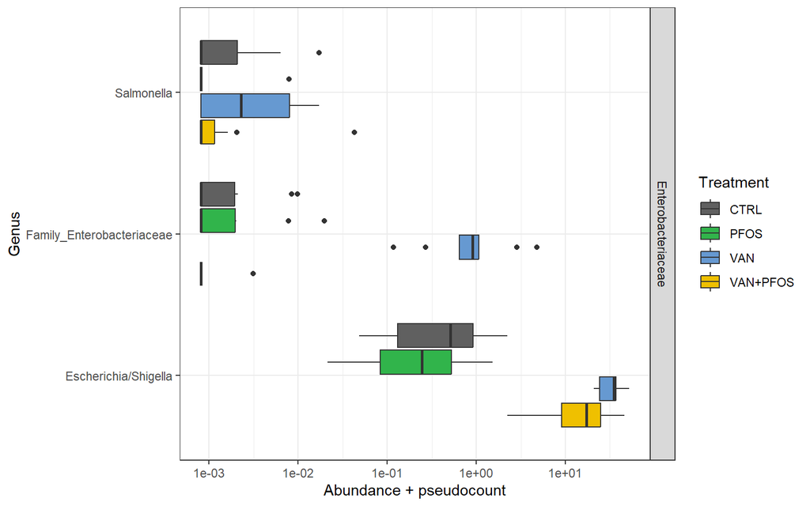

```r
# Plot data and save as output formats
p <- ggplot(t.melt, aes(Genus, Abundance+pseudocount, fill = fct_rev(treatment))) + geom_boxplot() + scale_y_log10() + coord_flip() + scale_fill_manual(values = params$COL, breaks=c("CTRL","PFOS","VAN","VAN+PFOS")) + facet_grid(Family ~ . , scales = "free_y", space = "free") + theme_bw() + labs(fill = "Treatment")
p
```

```r
suppressMessages(ggsave(paste0("plots/difabu/",SUBNAME,"/diffplot_",SUBNAME,"_",PDI,"_",LVL,"_",TX,".pdf"), p, device = "pdf", units = "mm", width = 200, height = 80, dpi = 300))
suppressMessages(ggsave(paste0("plots/difabu/",SUBNAME,"/diffplot_",SUBNAME,"_",PDI,"_",LVL,"_",TX,".png"), p, device = "png", units = "mm", width = 200, height = 80, dpi = 300))

# clear the environment and release memory
rm(list = ls(all.names = TRUE))
invisible(gc())
```

## 4.8 CONCLUSION

Three genera from the Enterobacteriaceae family are present in the fecal samples for day 8: Salmonella, Escherichia/Shigella and unclassified Family_Enterobacteriaceae. Common trend is lower abundance for all PFOS treated groups, where abundance is significantly and dramatically lower in the Family_Enterobacteriaceae taxon for the vancomycin treated groups.

# 5 ANALYSES NOT INCLUDED IN PUBLICATION

Following code chunks have been used in the processing of data but are not used for content of the paper.

# 6 DIFFERENTIAL ABUNDANCE OVER TIME

## 6.1 DAY CTRL TIME TEST DIFFERENTIAL ABUNDANCE

### 6.1.1 GENUS

#### 6.1.1.1 RUN DAtest

```r
params <- readRDS("R_objects/comp_params.RDS")

LVL <- "Genus"
MTRL <- "Feces"
TREAT <- "CTRL"
PDI <- "day"
SUBNAME <- "Feces_CTRL_all"
load(paste0("R_objects/Agglomerated_",SUBNAME,".RData"))

# Color scheme for days
    if (grepl("_CTRL",SUBNAME) == TRUE) {
      COL <- c("d0" = "#a0a0a0","d2" = "#808080","d4" = "#606060","d8" = "#494949")
    } else if (grepl("_PFOS",SUBNAME) == TRUE) {
      COL <- c("d0" = "#48ff62","d2" = "#45ce4b","d4" = "#31b44b","d8" = "#278937")
    } else if (grepl("_VANPFOS",SUBNAME) == TRUE) {
      COL <- c("d0" = "#f7e789","d2" = "#f7e054","d4" = "#fcdd05","d8" = "#c4a110")
    } else if (grepl("_VAN",SUBNAME) == TRUE) {
      COL <- c("d0" = "#8bd2fc","d2" = "#81c3ea","d4" = "#6699d1","d8" = "#487baa")
    }

# Create sub-folder
  if (!file.exists(paste0("plots/difabu/",SUBNAME))) dir.create(file.path(getwd(), paste0("plots/difabu/",SUBNAME)))

# Filter samples (if needed)
phy.ge <- subset_samples(phy.ge, material == MTRL & treatment == TREAT)

# Filter data
filt <- preDA(data = phy.ge, min.reads = 20, min.samples = 4)

# Run the selected analysis
filt.DA <- DA.aoa(filt, predictor = PDI)

# Evaluate the plot and summary table
table(filt.DA$pval.adj < 0.05)
filt.p5 <- filt.DA[filt.DA$pval.adj < 0.05,]
write.csv(filt.p5,paste0("plots/difabu/",SUBNAME,"/stats_",MTRL,"_",TREAT,"_",PDI,"_",LVL,".csv"))

# Create a subset of the samples
filt.ra <- transform_sample_counts(filt, function(x) x/sum(x)*100)
DA.sig <- prune_taxa(filt.DA$Feature[filt.DA$pval.adj < 0.05], x = filt.ra)

# melt the data
DAm <- psmelt(DA.sig)

# Create plot
pseudocount <- min(DAm$Abundance[DAm$Abundance != 0])
p.dif <- ggplot(DAm, aes(x = Genus, y = Abundance+pseudocount, fill = fct_rev(day))) + geom_boxplot() + scale_y_log10() + coord_flip() + scale_fill_manual(values = COL, breaks=c("d0","d2","d4","d8")) + facet_grid(Phylum ~ . , scales = "free_y", space = "free") + theme_bw() + labs(fill = "Day")
p.dT <- p.dif + ggtitle(paste0("Differential abundance on ",LVL," level for ",MTRL," ",TREAT))
p.dT

suppressMessages(ggsave(paste0("plots/difabu/",SUBNAME,"/diffplot_",SUBNAME,"_",TREAT,"_",PDI,"_",LVL,".pdf"), p.dif, device = "pdf", units = "mm", width = 350, height = 200, dpi = 300))
suppressMessages(ggsave(paste0("plots/difabu/",SUBNAME,"/diffplot_",SUBNAME,"_",TREAT,"_",PDI,"_",LVL,".png"), p.dif, device = "png", units = "mm", width = 350, height = 200, dpi = 300))

# clear the environment and release memory
rm(list = ls(all.names = TRUE))
invisible(gc())
```

### 6.1.2 FAMILY

#### 6.1.2.1 RUN DAtest

```r
params <- readRDS("R_objects/comp_params.RDS")

LVL <- "Family"
MTRL <- "Feces"
TREAT <- "CTRL"
PDI <- "day"
SUBNAME <- "Feces_CTRL_all"
load(paste0("R_objects/Agglomerated_",SUBNAME,".RData"))

# Color scheme for days
    if (grepl("_CTRL",SUBNAME) == TRUE) {
      COL <- c("d0" = "#a0a0a0","d2" = "#808080","d4" = "#606060","d8" = "#494949")
    } else if (grepl("_PFOS",SUBNAME) == TRUE) {
      COL <- c("d0" = "#48ff62","d2" = "#45ce4b","d4" = "#31b44b","d8" = "#278937")
    } else if (grepl("_VANPFOS",SUBNAME) == TRUE) {
      COL <- c("d0" = "#f7e789","d2" = "#f7e054","d4" = "#fcdd05","d8" = "#c4a110")
    } else if (grepl("_VAN",SUBNAME) == TRUE) {
      COL <- c("d0" = "#8bd2fc","d2" = "#81c3ea","d4" = "#6699d1","d8" = "#487baa")
    }

# Create sub-folder
  if (!file.exists(paste0("plots/difabu/",SUBNAME))) dir.create(file.path(getwd(), paste0("plots/difabu/",SUBNAME)))

# Filter samples (if needed)
phy.fa <- subset_samples(phy.fa, material == MTRL & treatment == TREAT)

# Filter data
filt <- preDA(data = phy.fa, min.reads = 20, min.samples = 4)

# Run the selected analysis
filt.DA <- DA.aoa(filt, predictor = PDI)

# Evaluate the plot and summary table
table(filt.DA$pval.adj < 0.05)
filt.p5 <- filt.DA[filt.DA$pval.adj < 0.05,]
write.csv(filt.p5,paste0("plots/difabu/",SUBNAME,"/stats_",MTRL,"_",TREAT,"_",PDI,"_",LVL,".csv"))

# Create a subset of the samples
filt.ra <- transform_sample_counts(filt, function(x) x/sum(x)*100)
DA.sig <- prune_taxa(filt.DA$Feature[filt.DA$pval.adj < 0.05], x = filt.ra)

# melt the data
DAm <- psmelt(DA.sig)

# Create plot
pseudocount <- min(DAm$Abundance[DAm$Abundance != 0])
p.dif <- ggplot(DAm, aes(x = Family, y = Abundance+pseudocount, fill = fct_rev(day))) + geom_boxplot() + scale_y_log10() + coord_flip() + scale_fill_manual(values = COL, breaks=c("d0","d2","d4","d8")) + facet_grid(Phylum ~ . , scales = "free_y", space = "free") + theme_bw() + labs(fill = "Day")
p.dT <- p.dif + ggtitle(paste0("Differential abundance on ",LVL," level for ",MTRL," ",TREAT))
p.dT

suppressMessages(ggsave(paste0("plots/difabu/",SUBNAME,"/diffplot_",SUBNAME,"_",TREAT,"_",PDI,"_",LVL,".pdf"), p.dif, device = "pdf", units = "mm", width = 350, height = 200, dpi = 300))
suppressMessages(ggsave(paste0("plots/difabu/",SUBNAME,"/diffplot_",SUBNAME,"_",TREAT,"_",PDI,"_",LVL,".png"), p.dif, device = "png", units = "mm", width = 350, height = 200, dpi = 300))

# clear the environment and release memory
rm(list = ls(all.names = TRUE))
invisible(gc())
```

## 6.2 DAY PFOS TIME TEST DIFFERENTIAL ABUNDANCE

### 6.2.1 GENUS

#### 6.2.1.1 RUN DAtest

```r
params <- readRDS("R_objects/comp_params.RDS")

LVL <- "Genus"
MTRL <- "Feces"
TREAT <- "PFOS"
PDI <- "day"
SUBNAME <- "Feces_PFOS_all"
load(paste0("R_objects/Agglomerated_",SUBNAME,".RData"))

# Color scheme for days
    if (grepl("_CTRL",SUBNAME) == TRUE) {
      COL <- c("d0" = "#a0a0a0","d2" = "#808080","d4" = "#606060","d8" = "#494949")
    } else if (grepl("_PFOS",SUBNAME) == TRUE) {
      COL <- c("d0" = "#48ff62","d2" = "#45ce4b","d4" = "#31b44b","d8" = "#278937")
    } else if (grepl("_VANPFOS",SUBNAME) == TRUE) {
      COL <- c("d0" = "#f7e789","d2" = "#f7e054","d4" = "#fcdd05","d8" = "#c4a110")
    } else if (grepl("_VAN",SUBNAME) == TRUE) {
      COL <- c("d0" = "#8bd2fc","d2" = "#81c3ea","d4" = "#6699d1","d8" = "#487baa")
    }

# Create sub-folder
  if (!file.exists(paste0("plots/difabu/",SUBNAME))) dir.create(file.path(getwd(), paste0("plots/difabu/",SUBNAME)))

# Filter samples (if needed)
phy.ge <- subset_samples(phy.ge, material == MTRL & treatment == TREAT)

# Filter data
filt <- preDA(data = phy.ge, min.reads = 20, min.samples = 4)

#### RUN DAtest
# Run the selected analysis
filt.DA <- DA.aoa(filt, predictor = PDI)

# Evaluate the plot and summary table
table(filt.DA$pval.adj < 0.05)
filt.p5 <- filt.DA[filt.DA$pval.adj < 0.05,]
write.csv(filt.p5,paste0("plots/difabu/",SUBNAME,"/stats_",MTRL,"_",TREAT,"_",PDI,"_",LVL,".csv"))

# Create a subset of the samples
filt.ra <- transform_sample_counts(filt, function(x) x/sum(x)*100)
DA.sig <- prune_taxa(filt.DA$Feature[filt.DA$pval.adj < 0.05], x = filt.ra)

# melt the data
DAm <- psmelt(DA.sig)

# Create plot
pseudocount <- min(DAm$Abundance[DAm$Abundance != 0])
p.dif <- ggplot(DAm, aes(x = Genus, y = Abundance+pseudocount, fill = fct_rev(day))) + geom_boxplot() + scale_y_log10() + coord_flip() + scale_fill_manual(values = COL, breaks=c("d0","d2","d4","d8")) + facet_grid(Phylum ~ . , scales = "free_y", space = "free") + theme_bw() + labs(fill = "Day")
p.dT <- p.dif + ggtitle(paste0("Differential abundance on ",LVL," level for ",MTRL," ",TREAT))
p.dT

suppressMessages(ggsave(paste0("plots/difabu/",SUBNAME,"/diffplot_",SUBNAME,"_",TREAT,"_",PDI,"_",LVL,".pdf"), p.dif, device = "pdf", units = "mm", width = 350, height = 200, dpi = 300))
suppressMessages(ggsave(paste0("plots/difabu/",SUBNAME,"/diffplot_",SUBNAME,"_",TREAT,"_",PDI,"_",LVL,".png"), p.dif, device = "png", units = "mm", width = 350, height = 200, dpi = 300))

# clear the environment and release memory
rm(list = ls(all.names = TRUE))
invisible(gc())
```

### 6.2.2 FAMILY

#### 6.2.2.1 RUN DAtest

```r
params <- readRDS("R_objects/comp_params.RDS")

LVL <- "Family"
MTRL <- "Feces"
TREAT <- "PFOS"
PDI <- "day"
SUBNAME <- "Feces_PFOS_all"
load(paste0("R_objects/Agglomerated_",SUBNAME,".RData"))

# Color scheme for days
    if (grepl("_CTRL",SUBNAME) == TRUE) {
      COL <- c("d0" = "#a0a0a0","d2" = "#808080","d4" = "#606060","d8" = "#494949")
    } else if (grepl("_PFOS",SUBNAME) == TRUE) {
      COL <- c("d0" = "#48ff62","d2" = "#45ce4b","d4" = "#31b44b","d8" = "#278937")
    } else if (grepl("_VANPFOS",SUBNAME) == TRUE) {
      COL <- c("d0" = "#f7e789","d2" = "#f7e054","d4" = "#fcdd05","d8" = "#c4a110")
    } else if (grepl("_VAN",SUBNAME) == TRUE) {
      COL <- c("d0" = "#8bd2fc","d2" = "#81c3ea","d4" = "#6699d1","d8" = "#487baa")
    }

# Create sub-folder
  if (!file.exists(paste0("plots/difabu/",SUBNAME))) dir.create(file.path(getwd(), paste0("plots/difabu/",SUBNAME)))

# Filter samples (if needed)
phy.fa <- subset_samples(phy.fa, material == MTRL & treatment == TREAT)

# Filter data
filt <- preDA(data = phy.fa, min.reads = 20, min.samples = 4)

# Run the selected analysis
filt.DA <- DA.aoc(filt, predictor = PDI)

# Evaluate the plot and summary table
table(filt.DA$pval.adj < 0.05)
filt.p5 <- filt.DA[filt.DA$pval.adj < 0.05,]
write.csv(filt.p5,paste0("plots/difabu/",SUBNAME,"/stats_",MTRL,"_",TREAT,"_",PDI,"_",LVL,".csv"))

# Create a subset of the samples
filt.ra <- transform_sample_counts(filt, function(x) x/sum(x)*100)
DA.sig <- prune_taxa(filt.DA$Feature[filt.DA$pval.adj < 0.05], x = filt.ra)

# melt the data
DAm <- psmelt(DA.sig)

# Create plot
pseudocount <- min(DAm$Abundance[DAm$Abundance != 0])
p.dif <- ggplot(DAm, aes(x = Family, y = Abundance+pseudocount, fill = fct_rev(day))) + geom_boxplot() + scale_y_log10() + coord_flip() + scale_fill_manual(values = COL, breaks=c("d0","d2","d4","d8")) + facet_grid(Phylum ~ . , scales = "free_y", space = "free") + theme_bw() + labs(fill = "Day")
p.dT <- p.dif + ggtitle(paste0("Differential abundance on ",LVL," level for ",MTRL," ",TREAT))
p.dT

suppressMessages(ggsave(paste0("plots/difabu/",SUBNAME,"/diffplot_",SUBNAME,"_",TREAT,"_",PDI,"_",LVL,".pdf"), p.dif, device = "pdf", units = "mm", width = 350, height = 200, dpi = 300))
suppressMessages(ggsave(paste0("plots/difabu/",SUBNAME,"/diffplot_",SUBNAME,"_",TREAT,"_",PDI,"_",LVL,".png"), p.dif, device = "png", units = "mm", width = 350, height = 200, dpi = 300))

# clear the environment and release memory
rm(list = ls(all.names = TRUE))
invisible(gc())
```

## 6.3 DAY VAN TIME TEST DIFFERENTIAL ABUNDANCE

### 6.3.1 GENUS

#### 6.3.1.1 RUN DAtest

```r
params <- readRDS("R_objects/comp_params.RDS")

LVL <- "Genus"
MTRL <- "Feces"
TREAT <- "VAN"
PDI <- "day"
SUBNAME <- "Feces_VAN_all"
load(paste0("R_objects/Agglomerated_",SUBNAME,".RData"))

# Color scheme for days
    if (grepl("_CTRL",SUBNAME) == TRUE) {
      COL <- c("d0" = "#a0a0a0","d2" = "#808080","d4" = "#606060","d8" = "#494949")
    } else if (grepl("_PFOS",SUBNAME) == TRUE) {
      COL <- c("d0" = "#48ff62","d2" = "#45ce4b","d4" = "#31b44b","d8" = "#278937")
    } else if (grepl("_VANPFOS",SUBNAME) == TRUE) {
      COL <- c("d0" = "#f7e789","d2" = "#f7e054","d4" = "#fcdd05","d8" = "#c4a110")
    } else if (grepl("_VAN",SUBNAME) == TRUE) {
      COL <- c("d0" = "#8bd2fc","d2" = "#81c3ea","d4" = "#6699d1","d8" = "#487baa")
    }

# Create sub-folder
  if (!file.exists(paste0("plots/difabu/",SUBNAME))) dir.create(file.path(getwd(), paste0("plots/difabu/",SUBNAME)))

# Filter samples (if needed)
phy.ge <- subset_samples(phy.ge, material == MTRL & treatment == TREAT)

# Filter data
filt <- preDA(data = phy.ge, min.reads = 20, min.samples = 4)

# Run the selected analysis
filt.DA <- DA.aoc(filt, predictor = PDI)

# Evaluate the plot and summary table
table(filt.DA$pval.adj < 0.05)
filt.p5 <- filt.DA[filt.DA$pval.adj < 0.05,]
write.csv(filt.p5,paste0("plots/difabu/",SUBNAME,"/stats_",MTRL,"_",TREAT,"_",PDI,"_",LVL,".csv"))

# Create a subset of the samples
filt.ra <- transform_sample_counts(filt, function(x) x/sum(x)*100)
DA.sig <- prune_taxa(filt.DA$Feature[filt.DA$pval.adj < 0.05], x = filt.ra)

# melt the data
DAm <- psmelt(DA.sig)

# Create plot
pseudocount <- min(DAm$Abundance[DAm$Abundance != 0])
p.dif <- ggplot(DAm, aes(x = Genus, y = Abundance+pseudocount, fill = fct_rev(day))) + geom_boxplot() + scale_y_log10() + coord_flip() + scale_fill_manual(values = COL, breaks=c("d0","d2","d4","d8")) + facet_grid(Phylum ~ . , scales = "free_y", space = "free") + theme_bw() + labs(fill = "Day")
p.dT <- p.dif + ggtitle(paste0("Differential abundance on ",LVL," level for ",MTRL," ",TREAT))
p.dT

suppressMessages(ggsave(paste0("plots/difabu/",SUBNAME,"/diffplot_",SUBNAME,"_",TREAT,"_",PDI,"_",LVL,".pdf"), p.dif, device = "pdf", units = "mm", width = 350, height = 500, dpi = 300))
suppressMessages(ggsave(paste0("plots/difabu/",SUBNAME,"/diffplot_",SUBNAME,"_",TREAT,"_",PDI,"_",LVL,".png"), p.dif, device = "png", units = "mm", width = 350, height = 500, dpi = 300))

# clear the environment and release memory
rm(list = ls(all.names = TRUE))
invisible(gc())
```

### 6.3.2 FAMILY

#### 6.3.2.1 RUN DAtest

```r
params <- readRDS("R_objects/comp_params.RDS")

LVL <- "Family"
MTRL <- "Feces"
TREAT <- "VAN"
PDI <- "day"
SUBNAME <- "Feces_VAN_all"
load(paste0("R_objects/Agglomerated_",SUBNAME,".RData"))

# Color scheme for days
    if (grepl("_CTRL",SUBNAME) == TRUE) {
      COL <- c("d0" = "#a0a0a0","d2" = "#808080","d4" = "#606060","d8" = "#494949")
    } else if (grepl("_PFOS",SUBNAME) == TRUE) {
      COL <- c("d0" = "#48ff62","d2" = "#45ce4b","d4" = "#31b44b","d8" = "#278937")
    } else if (grepl("_VANPFOS",SUBNAME) == TRUE) {
      COL <- c("d0" = "#f7e789","d2" = "#f7e054","d4" = "#fcdd05","d8" = "#c4a110")
    } else if (grepl("_VAN",SUBNAME) == TRUE) {
      COL <- c("d0" = "#8bd2fc","d2" = "#81c3ea","d4" = "#6699d1","d8" = "#487baa")
    }

# Create sub-folder
  if (!file.exists(paste0("plots/difabu/",SUBNAME))) dir.create(file.path(getwd(), paste0("plots/difabu/",SUBNAME)))

# Filter samples (if needed)
phy.fa <- subset_samples(phy.fa, material == MTRL & treatment == TREAT)

# Filter data
filt <- preDA(data = phy.fa, min.reads = 20, min.samples = 4)

# Run the selected analysis
filt.DA <- DA.aov(filt, predictor = PDI)

# Evaluate the plot and summary table
table(filt.DA$pval.adj < 0.05)
filt.p5 <- filt.DA[filt.DA$pval.adj < 0.05,]
write.csv(filt.p5,paste0("plots/difabu/",SUBNAME,"/stats_",MTRL,"_",TREAT,"_",PDI,"_",LVL,".csv"))

# Create a subset of the samples
filt.ra <- transform_sample_counts(filt, function(x) x/sum(x)*100)
DA.sig <- prune_taxa(filt.DA$Feature[filt.DA$pval.adj < 0.05], x = filt.ra)

# melt the data
DAm <- psmelt(DA.sig)

# Create plot
pseudocount <- min(DAm$Abundance[DAm$Abundance != 0])
p.dif <- ggplot(DAm, aes(x = Family, y = Abundance+pseudocount, fill = fct_rev(day))) + geom_boxplot() + scale_y_log10() + coord_flip() + scale_fill_manual(values = COL, breaks=c("d0","d2","d4","d8")) + facet_grid(Phylum ~ . , scales = "free_y", space = "free") + theme_bw() + labs(fill = "Day")
p.dT <- p.dif + ggtitle(paste0("Differential abundance on ",LVL," level for ",MTRL," ",TREAT))
p.dT

suppressMessages(ggsave(paste0("plots/difabu/",SUBNAME,"/diffplot_",SUBNAME,"_",TREAT,"_",PDI,"_",LVL,".pdf"), p.dif, device = "pdf", units = "mm", width = 350, height = 500, dpi = 300))
suppressMessages(ggsave(paste0("plots/difabu/",SUBNAME,"/diffplot_",SUBNAME,"_",TREAT,"_",PDI,"_",LVL,".png"), p.dif, device = "png", units = "mm", width = 350, height = 500, dpi = 300))

# clear the environment and release memory
rm(list = ls(all.names = TRUE))
invisible(gc())
```

## 6.4 DAY VAN+PFOS TIME TEST DIFFERENTIAL ABUNDANCE

### 6.4.1 GENUS

#### 6.4.1.1 RUN DAtest

```r
params <- readRDS("R_objects/comp_params.RDS")

LVL <- "Genus"
MTRL <- "Feces"
TREAT <- "VAN+PFOS"
PDI <- "day"
SUBNAME <- "Feces_VANPFOS_all"
load(paste0("R_objects/Agglomerated_",SUBNAME,".RData"))

# Color scheme for days
    if (grepl("_CTRL",SUBNAME) == TRUE) {
      COL <- c("d0" = "#a0a0a0","d2" = "#808080","d4" = "#606060","d8" = "#494949")
    } else if (grepl("_PFOS",SUBNAME) == TRUE) {
      COL <- c("d0" = "#48ff62","d2" = "#45ce4b","d4" = "#31b44b","d8" = "#278937")
    } else if (grepl("_VANPFOS",SUBNAME) == TRUE) {
      COL <- c("d0" = "#f7e789","d2" = "#f7e054","d4" = "#fcdd05","d8" = "#c4a110")
    } else if (grepl("_VAN",SUBNAME) == TRUE) {
      COL <- c("d0" = "#8bd2fc","d2" = "#81c3ea","d4" = "#6699d1","d8" = "#487baa")
    }

# Create sub-folder
  if (!file.exists(paste0("plots/difabu/",SUBNAME))) dir.create(file.path(getwd(), paste0("plots/difabu/",SUBNAME)))

# Filter samples (if needed)
phy.ge <- subset_samples(phy.ge, material == MTRL & treatment == TREAT)

# Filter data
filt <- preDA(data = phy.ge, min.reads = 20, min.samples = 4)

# Run the selected analysis
filt.DA <- DA.lao2(filt, predictor = PDI)

# Evaluate the plot and summary table
table(filt.DA$pval.adj < 0.05)
filt.p5 <- filt.DA[filt.DA$pval.adj < 0.05,]
write.csv(filt.p5,paste0("plots/difabu/",SUBNAME,"/stats_",MTRL,"_",TREAT,"_",PDI,"_",LVL,".csv"))

# Create a subset of the samples
filt.ra <- transform_sample_counts(filt, function(x) x/sum(x)*100)
DA.sig <- prune_taxa(filt.DA$Feature[filt.DA$pval.adj < 0.05], x = filt.ra)

# melt the data
DAm <- psmelt(DA.sig)

# Create plot
pseudocount <- min(DAm$Abundance[DAm$Abundance != 0])
p.dif <- ggplot(DAm, aes(x = Genus, y = Abundance+pseudocount, fill = fct_rev(day))) + geom_boxplot() + scale_y_log10() + coord_flip() + scale_fill_manual(values = COL, breaks=c("d0","d2","d4","d8")) + facet_grid(Phylum ~ . , scales = "free_y", space = "free") + theme_bw() + labs(fill = "Day")
p.dT <- p.dif + ggtitle(paste0("Differential abundance on ",LVL," level for ",MTRL," ",TREAT))
p.dT

suppressMessages(ggsave(paste0("plots/difabu/",SUBNAME,"/diffplot_",SUBNAME,"_",TREAT,"_",PDI,"_",LVL,".pdf"), p.dif, device = "pdf", units = "mm", width = 350, height = 500, dpi = 300))
suppressMessages(ggsave(paste0("plots/difabu/",SUBNAME,"/diffplot_",SUBNAME,"_",TREAT,"_",PDI,"_",LVL,".png"), p.dif, device = "png", units = "mm", width = 350, height = 500, dpi = 300))

# clear the environment and release memory
rm(list = ls(all.names = TRUE))
invisible(gc())
```

### 6.4.2 FAMILY

#### 6.4.2.1 RUN DAtest

```r
params <- readRDS("R_objects/comp_params.RDS")

LVL <- "Family"
MTRL <- "Feces"
TREAT <- "VAN+PFOS"
PDI <- "day"
SUBNAME <- "Feces_VANPFOS_all"
load(paste0("R_objects/Agglomerated_",SUBNAME,".RData"))

# Color scheme for days
    if (grepl("_CTRL",SUBNAME) == TRUE) {
      COL <- c("d0" = "#a0a0a0","d2" = "#808080","d4" = "#606060","d8" = "#494949")
    } else if (grepl("_PFOS",SUBNAME) == TRUE) {
      COL <- c("d0" = "#48ff62","d2" = "#45ce4b","d4" = "#31b44b","d8" = "#278937")
    } else if (grepl("_VANPFOS",SUBNAME) == TRUE) {
      COL <- c("d0" = "#f7e789","d2" = "#f7e054","d4" = "#fcdd05","d8" = "#c4a110")
    } else if (grepl("_VAN",SUBNAME) == TRUE) {
      COL <- c("d0" = "#8bd2fc","d2" = "#81c3ea","d4" = "#6699d1","d8" = "#487baa")
    }

# Create sub-folder
  if (!file.exists(paste0("plots/difabu/",SUBNAME))) dir.create(file.path(getwd(), paste0("plots/difabu/",SUBNAME)))

# Filter samples (if needed)
phy.fa <- subset_samples(phy.fa, material == MTRL & treatment == TREAT)

# Filter data
filt <- preDA(data = phy.fa, min.reads = 20, min.samples = 4)

# Run the selected analysis
filt.DA <- DA.aov(filt, predictor = PDI)

# Evaluate the plot and summary table
table(filt.DA$pval.adj < 0.05)
filt.p5 <- filt.DA[filt.DA$pval.adj < 0.05,]
write.csv(filt.p5,paste0("plots/difabu/",SUBNAME,"/stats_",MTRL,"_",TREAT,"_",PDI,"_",LVL,".csv"))

# Create a subset of the samples
filt.ra <- transform_sample_counts(filt, function(x) x/sum(x)*100)
DA.sig <- prune_taxa(filt.DA$Feature[filt.DA$pval.adj < 0.05], x = filt.ra)

# melt the data
DAm <- psmelt(DA.sig)

# Create plot
pseudocount <- min(DAm$Abundance[DAm$Abundance != 0])
p.dif <- ggplot(DAm, aes(x = Family, y = Abundance+pseudocount, fill = fct_rev(day))) + geom_boxplot() + scale_y_log10() + coord_flip() + scale_fill_manual(values = COL, breaks=c("d0","d2","d4","d8")) + facet_grid(Phylum ~ . , scales = "free_y", space = "free") + theme_bw() + labs(fill = "Day")
p.dT <- p.dif + ggtitle(paste0("Differential abundance on ",LVL," level for ",MTRL," ",TREAT))
p.dT

suppressMessages(ggsave(paste0("plots/difabu/",SUBNAME,"/diffplot_",SUBNAME,"_",TREAT,"_",PDI,"_",LVL,".pdf"), p.dif, device = "pdf", units = "mm", width = 350, height = 500, dpi = 300))
suppressMessages(ggsave(paste0("plots/difabu/",SUBNAME,"/diffplot_",SUBNAME,"_",TREAT,"_",PDI,"_",LVL,".png"), p.dif, device = "png", units = "mm", width = 350, height = 500, dpi = 300))

# clear the environment and release memory
rm(list = ls(all.names = TRUE))
invisible(gc())
```

# 7 OTHER DIFFERENTIAL ABUNDANCE ANALYSES

## 7.1 FECES d08 CTRL TEST DIFFERENTIAL ABUNDANCE

### 7.1.1 GENUS

#### 7.1.1.1 RUN DAtest

```r
params <- readRDS("R_objects/comp_params.RDS")

LVL <- "Genus"
MTRL <- "Feces"
TREAT <- "CTRL"
DAY <- "d0d8"
PDI <- "day"
SUBNAME <- "Feces_d0d8"
load(paste0("R_objects/Agglomerated_",SUBNAME,".RData"))

# Color scheme for days
    if (TREAT == "CTRL") {
      COL <- c("d0" = "#a0a0a0","d2" = "#808080","d4" = "#606060","d8" = "#494949")
    } else if (TREAT == "PFOS") {
      COL <- c("d0" = "#48ff62","d2" = "#45ce4b","d4" = "#31b44b","d8" = "#278937")
    } else if (TREAT == "VAN+PFOS") {
      COL <- c("d0" = "#f7e789","d2" = "#f7e054","d4" = "#fcdd05","d8" = "#c4a110")
    } else if (TREAT == "VAN") {
      COL <- c("d0" = "#8bd2fc","d2" = "#81c3ea","d4" = "#6699d1","d8" = "#487baa")
    }

# Create sub-folder
  if (!file.exists(paste0("plots/difabu/",SUBNAME))) dir.create(file.path(getwd(), paste0("plots/difabu/",SUBNAME)))

# Filter samples (if needed)
phy.ge <- subset_samples(phy.ge, material == MTRL & treatment == TREAT)

# Filter data
filt <- preDA(data = phy.ge, min.reads = 20, min.samples = 4)

# Run the selected analysis
filt.DA <- DA.tta(filt, predictor = PDI)

# Evaluate the plot and summary table
table(filt.DA$pval.adj < 0.05)
filt.p5 <- filt.DA[filt.DA$pval.adj < 0.05,]
filt.p5
write.csv(filt.p5,paste0("plots/difabu/",SUBNAME,"/stats_",MTRL,"_",TREAT,"_",DAY,"_",PDI,"_",LVL,".csv"))

# Create a subset of the samples
filt.ra <- transform_sample_counts(filt, function(x) x/sum(x)*100)
DA.sig <- prune_taxa(filt.DA$Feature[filt.DA$pval.adj < 0.05], x = filt.ra)

# melt the data
DAm <- psmelt(DA.sig)

# Create plot
pseudocount <- min(DAm$Abundance[DAm$Abundance != 0])
p.dif <- ggplot(DAm, aes(x = Genus, y = Abundance+pseudocount, fill = fct_rev(day))) + geom_boxplot() + scale_y_log10() + coord_flip() + scale_fill_manual(values = COL, breaks=c("d0","d2","d4","d8")) + facet_grid(Phylum ~ . , scales = "free_y", space = "free") + theme_bw() + labs(fill = "Day")
p.dT <- p.dif + ggtitle(paste0("Differential abundance on ",LVL," level for ",MTRL," ",TREAT))
p.dT

suppressMessages(ggsave(paste0("plots/difabu/",SUBNAME,"/diffplot_",SUBNAME,"_",TREAT,"_",PDI,"_",LVL,".pdf"), p.dif, device = "pdf", units = "mm", width = 350, height = 100, dpi = 300))
suppressMessages(ggsave(paste0("plots/difabu/",SUBNAME,"/diffplot_",SUBNAME,"_",TREAT,"_",PDI,"_",LVL,".png"), p.dif, device = "png", units = "mm", width = 350, height = 100, dpi = 300))

# clear the environment and release memory
rm(list = ls(all.names = TRUE))
invisible(gc())
```

### 7.1.2 FAMILY

#### 7.1.2.1 RUN DAtest

```r
params <- readRDS("R_objects/comp_params.RDS")

LVL <- "Family"
MTRL <- "Feces"
TREAT <- "CTRL"
DAY <- "d0d8"
PDI <- "day"
SUBNAME <- "Feces_d0d8"
load(paste0("R_objects/Agglomerated_",SUBNAME,".RData"))

# Color scheme for days
    if (TREAT == "CTRL") {
      COL <- c("d0" = "#a0a0a0","d2" = "#808080","d4" = "#606060","d8" = "#494949")
    } else if (TREAT == "PFOS") {
      COL <- c("d0" = "#48ff62","d2" = "#45ce4b","d4" = "#31b44b","d8" = "#278937")
    } else if (TREAT == "VAN+PFOS") {
      COL <- c("d0" = "#f7e789","d2" = "#f7e054","d4" = "#fcdd05","d8" = "#c4a110")
    } else if (TREAT == "VAN") {
      COL <- c("d0" = "#8bd2fc","d2" = "#81c3ea","d4" = "#6699d1","d8" = "#487baa")
    }

# Create sub-folder
  if (!file.exists(paste0("plots/difabu/",SUBNAME))) dir.create(file.path(getwd(), paste0("plots/difabu/",SUBNAME)))

# Filter samples (if needed)
phy.fa <- subset_samples(phy.fa, material == MTRL & treatment == TREAT)

# Filter data
filt <- preDA(data = phy.fa, min.reads = 20, min.samples = 4)

# Run the selected analysis
filt.DA <- DA.tta(filt, predictor = PDI)

# Evaluate the plot and summary table
table(filt.DA$pval.adj < 0.05)
filt.p5 <- filt.DA[filt.DA$pval.adj < 0.05,]
filt.p5
write.csv(filt.p5,paste0("plots/difabu/",SUBNAME,"/stats_",MTRL,"_",TREAT,"_",DAY,"_",PDI,"_",LVL,".csv"))

# Create a subset of the samples
filt.ra <- transform_sample_counts(filt, function(x) x/sum(x)*100)
DA.sig <- prune_taxa(filt.DA$Feature[filt.DA$pval.adj < 0.05], x = filt.ra)

# melt the data
DAm <- psmelt(DA.sig)

# Create plot
pseudocount <- min(DAm$Abundance[DAm$Abundance != 0])
p.dif <- ggplot(DAm, aes(x = Family, y = Abundance+pseudocount, fill = fct_rev(day))) + geom_boxplot() + scale_y_log10() + coord_flip() + scale_fill_manual(values = COL, breaks=c("d0","d2","d4","d8")) + facet_grid(Phylum ~ . , scales = "free_y", space = "free") + theme_bw() + labs(fill = "Day")
p.dT <- p.dif + ggtitle(paste0("Differential abundance on ",LVL," level for ",MTRL," ",TREAT))
p.dT

suppressMessages(ggsave(paste0("plots/difabu/",SUBNAME,"/diffplot_",SUBNAME,"_",TREAT,"_",PDI,"_",LVL,".pdf"), p.dif, device = "pdf", units = "mm", width = 350, height = 200, dpi = 300))
suppressMessages(ggsave(paste0("plots/difabu/",SUBNAME,"/diffplot_",SUBNAME,"_",TREAT,"_",PDI,"_",LVL,".png"), p.dif, device = "png", units = "mm", width = 350, height = 200, dpi = 300))

# clear the environment and release memory
rm(list = ls(all.names = TRUE))
invisible(gc())
```

## 7.2 FECES d08 PFOS TEST DIFFERENTIAL ABUNDANCE

### 7.2.1 GENUS

#### 7.2.1.1 RUN DAtest

```r
params <- readRDS("R_objects/comp_params.RDS")

LVL <- "Genus"
MTRL <- "Feces"
TREAT <- "PFOS"
DAY <- "d0d8"
PDI <- "day"
SUBNAME <- "Feces_d0d8"
load(paste0("R_objects/Agglomerated_",SUBNAME,".RData"))

# Color scheme for days
    if (TREAT == "CTRL") {
      COL <- c("d0" = "#a0a0a0","d2" = "#808080","d4" = "#606060","d8" = "#494949")
    } else if (TREAT == "PFOS") {
      COL <- c("d0" = "#48ff62","d2" = "#45ce4b","d4" = "#31b44b","d8" = "#278937")
    } else if (TREAT == "VAN+PFOS") {
      COL <- c("d0" = "#f7e789","d2" = "#f7e054","d4" = "#fcdd05","d8" = "#c4a110")
    } else if (TREAT == "VAN") {
      COL <- c("d0" = "#8bd2fc","d2" = "#81c3ea","d4" = "#6699d1","d8" = "#487baa")
    }

# Create sub-folder
  if (!file.exists(paste0("plots/difabu/",SUBNAME))) dir.create(file.path(getwd(), paste0("plots/difabu/",SUBNAME)))

# Filter samples (if needed)
phy.ge <- subset_samples(phy.ge, material == MTRL & treatment == TREAT)

# Filter data
filt <- preDA(data = phy.ge, min.reads = 20, min.samples = 4)

# Run the selected analysis
filt.DA <- DA.tta(filt, predictor = PDI)

# Evaluate the plot and summary table
table(filt.DA$pval.adj < 0.05)
filt.p5 <- filt.DA[filt.DA$pval.adj < 0.05,]
filt.p5
write.csv(filt.p5,paste0("plots/difabu/",SUBNAME,"/stats_",MTRL,"_",TREAT,"_",DAY,"_",PDI,"_",LVL,".csv"))

# Create a subset of the samples
filt.ra <- transform_sample_counts(filt, function(x) x/sum(x)*100)
DA.sig <- prune_taxa(filt.DA$Feature[filt.DA$pval.adj < 0.05], x = filt.ra)

# melt the data
DAm <- psmelt(DA.sig)

# Create plot
pseudocount <- min(DAm$Abundance[DAm$Abundance != 0])
p.dif <- ggplot(DAm, aes(x = Genus, y = Abundance+pseudocount, fill = fct_rev(day))) + geom_boxplot() + scale_y_log10() + coord_flip() + scale_fill_manual(values = COL, breaks=c("d0","d2","d4","d8")) + facet_grid(Phylum ~ . , scales = "free_y", space = "free") + theme_bw() + labs(fill = "Day")
p.dT <- p.dif + ggtitle(paste0("Differential abundance on ",LVL," level for ",MTRL," ",TREAT))
p.dT

suppressMessages(ggsave(paste0("plots/difabu/",SUBNAME,"/diffplot_",SUBNAME,"_",TREAT,"_",PDI,"_",LVL,".pdf"), p.dif, device = "pdf", units = "mm", width = 350, height = 100, dpi = 300))
suppressMessages(ggsave(paste0("plots/difabu/",SUBNAME,"/diffplot_",SUBNAME,"_",TREAT,"_",PDI,"_",LVL,".png"), p.dif, device = "png", units = "mm", width = 350, height = 100, dpi = 300))

# clear the environment and release memory
rm(list = ls(all.names = TRUE))
invisible(gc())
```

### 7.2.2 FAMILY

#### 7.2.2.1 RUN DAtest

```r
params <- readRDS("R_objects/comp_params.RDS")

LVL <- "Family"
MTRL <- "Feces"
TREAT <- "PFOS"
DAY <- "d0d8"
PDI <- "day"
SUBNAME <- "Feces_d0d8"
load(paste0("R_objects/Agglomerated_",SUBNAME,".RData"))

# Color scheme for days
    if (TREAT == "CTRL") {
      COL <- c("d0" = "#a0a0a0","d2" = "#808080","d4" = "#606060","d8" = "#494949")
    } else if (TREAT == "PFOS") {
      COL <- c("d0" = "#48ff62","d2" = "#45ce4b","d4" = "#31b44b","d8" = "#278937")
    } else if (TREAT == "VAN+PFOS") {
      COL <- c("d0" = "#f7e789","d2" = "#f7e054","d4" = "#fcdd05","d8" = "#c4a110")
    } else if (TREAT == "VAN") {
      COL <- c("d0" = "#8bd2fc","d2" = "#81c3ea","d4" = "#6699d1","d8" = "#487baa")
    }

# Create sub-folder
  if (!file.exists(paste0("plots/difabu/",SUBNAME))) dir.create(file.path(getwd(), paste0("plots/difabu/",SUBNAME)))

# Filter samples (if needed)
phy.fa <- subset_samples(phy.fa, material == MTRL & treatment == TREAT)

# Filter data
filt <- preDA(data = phy.fa, min.reads = 20, min.samples = 4)

# Run the selected analysis
filt.DA <- DA.tta(filt, predictor = PDI)

# Evaluate the plot and summary table
table(filt.DA$pval.adj < 0.05)
filt.p5 <- filt.DA[filt.DA$pval.adj < 0.05,]
filt.p5
write.csv(filt.p5,paste0("plots/difabu/",SUBNAME,"/stats_",MTRL,"_",TREAT,"_",DAY,"_",PDI,"_",LVL,".csv"))

# Create a subset of the samples
filt.ra <- transform_sample_counts(filt, function(x) x/sum(x)*100)
DA.sig <- prune_taxa(filt.DA$Feature[filt.DA$pval.adj < 0.05], x = filt.ra)

# melt the data
DAm <- psmelt(DA.sig)

# Create plot
pseudocount <- min(DAm$Abundance[DAm$Abundance != 0])
p.dif <- ggplot(DAm, aes(x = Family, y = Abundance+pseudocount, fill = fct_rev(day))) + geom_boxplot() + scale_y_log10() + coord_flip() + scale_fill_manual(values = COL, breaks=c("d0","d2","d4","d8")) + facet_grid(Phylum ~ . , scales = "free_y", space = "free") + theme_bw() + labs(fill = "Day")
p.dT <- p.dif + ggtitle(paste0("Differential abundance on ",LVL," level for ",MTRL," ",TREAT))
p.dT

suppressMessages(ggsave(paste0("plots/difabu/",SUBNAME,"/diffplot_",SUBNAME,"_",TREAT,"_",PDI,"_",LVL,".pdf"), p.dif, device = "pdf", units = "mm", width = 350, height = 200, dpi = 300))
suppressMessages(ggsave(paste0("plots/difabu/",SUBNAME,"/diffplot_",SUBNAME,"_",TREAT,"_",PDI,"_",LVL,".png"), p.dif, device = "png", units = "mm", width = 350, height = 200, dpi = 300))

# clear the environment and release memory
rm(list = ls(all.names = TRUE))
invisible(gc())
```

## 7.3 FECES d08 VAN TEST DIFFERENTIAL ABUNDANCE

### 7.3.1 GENUS

#### 7.3.1.1 RUN DAtest

```r
params <- readRDS("R_objects/comp_params.RDS")

LVL <- "Genus"
MTRL <- "Feces"
TREAT <- "VAN"
DAY <- "d0d8"
PDI <- "day"
SUBNAME <- "Feces_d0d8"
load(paste0("R_objects/Agglomerated_",SUBNAME,".RData"))

# Color scheme for days
    if (TREAT == "CTRL") {
      COL <- c("d0" = "#a0a0a0","d2" = "#808080","d4" = "#606060","d8" = "#494949")
    } else if (TREAT == "PFOS") {
      COL <- c("d0" = "#48ff62","d2" = "#45ce4b","d4" = "#31b44b","d8" = "#278937")
    } else if (TREAT == "VAN+PFOS") {
      COL <- c("d0" = "#f7e789","d2" = "#f7e054","d4" = "#fcdd05","d8" = "#c4a110")
    } else if (TREAT == "VAN") {
      COL <- c("d0" = "#8bd2fc","d2" = "#81c3ea","d4" = "#6699d1","d8" = "#487baa")
    }

# Create sub-folder
  if (!file.exists(paste0("plots/difabu/",SUBNAME))) dir.create(file.path(getwd(), paste0("plots/difabu/",SUBNAME)))

# Filter samples (if needed)
phy.ge <- subset_samples(phy.ge, material == MTRL & treatment == TREAT)

# Filter data
filt <- preDA(data = phy.ge, min.reads = 20, min.samples = 4)

# Run the selected analysis
filt.DA <- DA.tta(filt, predictor = PDI)

# Evaluate the plot and summary table
table(filt.DA$pval.adj < 0.05)
filt.p5 <- filt.DA[filt.DA$pval.adj < 0.05,]
filt.p5
write.csv(filt.p5,paste0("plots/difabu/",SUBNAME,"/stats_",MTRL,"_",TREAT,"_",DAY,"_",PDI,"_",LVL,".csv"))

# Create a subset of the samples
filt.ra <- transform_sample_counts(filt, function(x) x/sum(x)*100)
DA.sig <- prune_taxa(filt.DA$Feature[filt.DA$pval.adj < 0.05], x = filt.ra)

# melt the data
DAm <- psmelt(DA.sig)

# Create plot
pseudocount <- min(DAm$Abundance[DAm$Abundance != 0])
p.dif <- ggplot(DAm, aes(x = Genus, y = Abundance+pseudocount, fill = fct_rev(day))) + geom_boxplot() + scale_y_log10() + coord_flip() + scale_fill_manual(values = COL, breaks=c("d0","d2","d4","d8")) + facet_grid(Phylum ~ . , scales = "free_y", space = "free") + theme_bw() + labs(fill = "Day")
p.dT <- p.dif + ggtitle(paste0("Differential abundance on ",LVL," level for ",MTRL," ",TREAT))
p.dT

suppressMessages(ggsave(paste0("plots/difabu/",SUBNAME,"/diffplot_",SUBNAME,"_",TREAT,"_",PDI,"_",LVL,".pdf"), p.dif, device = "pdf", units = "mm", width = 350, height = 500, dpi = 300))
suppressMessages(ggsave(paste0("plots/difabu/",SUBNAME,"/diffplot_",SUBNAME,"_",TREAT,"_",PDI,"_",LVL,".png"), p.dif, device = "png", units = "mm", width = 350, height = 500, dpi = 300))

# clear the environment and release memory
rm(list = ls(all.names = TRUE))
invisible(gc())
```

### 7.3.2 FAMILY

#### 7.3.2.1 RUN DAtest

```r
params <- readRDS("R_objects/comp_params.RDS")

LVL <- "Family"
MTRL <- "Feces"
TREAT <- "VAN"
DAY <- "d0d8"
PDI <- "day"
SUBNAME <- "Feces_d0d8"
load(paste0("R_objects/Agglomerated_",SUBNAME,".RData"))

# Color scheme for days
    if (TREAT == "CTRL") {
      COL <- c("d0" = "#a0a0a0","d2" = "#808080","d4" = "#606060","d8" = "#494949")
    } else if (TREAT == "PFOS") {
      COL <- c("d0" = "#48ff62","d2" = "#45ce4b","d4" = "#31b44b","d8" = "#278937")
    } else if (TREAT == "VAN+PFOS") {
      COL <- c("d0" = "#f7e789","d2" = "#f7e054","d4" = "#fcdd05","d8" = "#c4a110")
    } else if (TREAT == "VAN") {
      COL <- c("d0" = "#8bd2fc","d2" = "#81c3ea","d4" = "#6699d1","d8" = "#487baa")
    }

# Create sub-folder
  if (!file.exists(paste0("plots/difabu/",SUBNAME))) dir.create(file.path(getwd(), paste0("plots/difabu/",SUBNAME)))

# Filter samples (if needed)
phy.fa <- subset_samples(phy.fa, material == MTRL & treatment == TREAT)

# Filter data
filt <- preDA(data = phy.fa, min.reads = 20, min.samples = 4)

# Run the selected analysis
filt.DA <- DA.tta(filt, predictor = PDI)

# Evaluate the plot and summary table
table(filt.DA$pval.adj < 0.05)
filt.p5 <- filt.DA[filt.DA$pval.adj < 0.05,]
filt.p5
write.csv(filt.p5,paste0("plots/difabu/",SUBNAME,"/stats_",MTRL,"_",TREAT,"_",DAY,"_",PDI,"_",LVL,".csv"))

# Create a subset of the samples
filt.ra <- transform_sample_counts(filt, function(x) x/sum(x)*100)
DA.sig <- prune_taxa(filt.DA$Feature[filt.DA$pval.adj < 0.05], x = filt.ra)

# melt the data
DAm <- psmelt(DA.sig)

# Create plot
pseudocount <- min(DAm$Abundance[DAm$Abundance != 0])
p.dif <- ggplot(DAm, aes(x = Family, y = Abundance+pseudocount, fill = fct_rev(day))) + geom_boxplot() + scale_y_log10() + coord_flip() + scale_fill_manual(values = COL, breaks=c("d0","d2","d4","d8")) + facet_grid(Phylum ~ . , scales = "free_y", space = "free") + theme_bw() + labs(fill = "Day")
p.dT <- p.dif + ggtitle(paste0("Differential abundance on ",LVL," level for ",MTRL," ",TREAT))
p.dT

suppressMessages(ggsave(paste0("plots/difabu/",SUBNAME,"/diffplot_",SUBNAME,"_",TREAT,"_",PDI,"_",LVL,".pdf"), p.dif, device = "pdf", units = "mm", width = 350, height = 200, dpi = 300))
suppressMessages(ggsave(paste0("plots/difabu/",SUBNAME,"/diffplot_",SUBNAME,"_",TREAT,"_",PDI,"_",LVL,".png"), p.dif, device = "png", units = "mm", width = 350, height = 200, dpi = 300))

# clear the environment and release memory
rm(list = ls(all.names = TRUE))
invisible(gc())
```

## 7.4 FECES d08 VAN+PFOS TEST DIFFERENTIAL ABUNDANCE

### 7.4.1 GENUS

#### 7.4.1.1 RUN DAtest

```r
params <- readRDS("R_objects/comp_params.RDS")

LVL <- "Genus"
MTRL <- "Feces"
TREAT <- "VAN+PFOS"
DAY <- "d0d8"
PDI <- "day"
SUBNAME <- "Feces_d0d8"
load(paste0("R_objects/Agglomerated_",SUBNAME,".RData"))

# Color scheme for days
    if (TREAT == "CTRL") {
      COL <- c("d0" = "#a0a0a0","d2" = "#808080","d4" = "#606060","d8" = "#494949")
    } else if (TREAT == "PFOS") {
      COL <- c("d0" = "#48ff62","d2" = "#45ce4b","d4" = "#31b44b","d8" = "#278937")
    } else if (TREAT == "VAN+PFOS") {
      COL <- c("d0" = "#f7e789","d2" = "#f7e054","d4" = "#fcdd05","d8" = "#c4a110")
    } else if (TREAT == "VAN") {
      COL <- c("d0" = "#8bd2fc","d2" = "#81c3ea","d4" = "#6699d1","d8" = "#487baa")
    }

# Create sub-folder
  if (!file.exists(paste0("plots/difabu/",SUBNAME))) dir.create(file.path(getwd(), paste0("plots/difabu/",SUBNAME)))

# Filter samples (if needed)
phy.ge <- subset_samples(phy.ge, material == MTRL & treatment == TREAT)

# Filter data
filt <- preDA(data = phy.ge, min.reads = 20, min.samples = 4)

# Run the selected analysis
filt.DA <- DA.tta(filt, predictor = PDI)

# Evaluate the plot and summary table
table(filt.DA$pval.adj < 0.05)
filt.p5 <- filt.DA[filt.DA$pval.adj < 0.05,]
filt.p5
write.csv(filt.p5,paste0("plots/difabu/",SUBNAME,"/stats_",MTRL,"_",TREAT,"_",DAY,"_",PDI,"_",LVL,".csv"))

# Create a subset of the samples
filt.ra <- transform_sample_counts(filt, function(x) x/sum(x)*100)
DA.sig <- prune_taxa(filt.DA$Feature[filt.DA$pval.adj < 0.05], x = filt.ra)

# melt the data
DAm <- psmelt(DA.sig)

# Create plot
pseudocount <- min(DAm$Abundance[DAm$Abundance != 0])
p.dif <- ggplot(DAm, aes(x = Genus, y = Abundance+pseudocount, fill = fct_rev(day))) + geom_boxplot() + scale_y_log10() + coord_flip() + scale_fill_manual(values = COL, breaks=c("d0","d2","d4","d8")) + facet_grid(Phylum ~ . , scales = "free_y", space = "free") + theme_bw() + labs(fill = "Day")
p.dT <- p.dif + ggtitle(paste0("Differential abundance on ",LVL," level for ",MTRL," ",TREAT))
p.dT

suppressMessages(ggsave(paste0("plots/difabu/",SUBNAME,"/diffplot_",SUBNAME,"_",TREAT,"_",PDI,"_",LVL,".pdf"), p.dif, device = "pdf", units = "mm", width = 350, height = 500, dpi = 300))
suppressMessages(ggsave(paste0("plots/difabu/",SUBNAME,"/diffplot_",SUBNAME,"_",TREAT,"_",PDI,"_",LVL,".png"), p.dif, device = "png", units = "mm", width = 350, height = 500, dpi = 300))

# clear the environment and release memory
rm(list = ls(all.names = TRUE))
invisible(gc())
```

### 7.4.2 FAMILY

#### 7.4.2.1 RUN DAtest

```r
params <- readRDS("R_objects/comp_params.RDS")

LVL <- "Family"
MTRL <- "Feces"
TREAT <- "VAN+PFOS"
DAY <- "d0d8"
PDI <- "day"
SUBNAME <- "Feces_d0d8"
load(paste0("R_objects/Agglomerated_",SUBNAME,".RData"))

# Color scheme for days
    if (TREAT == "CTRL") {
      COL <- c("d0" = "#a0a0a0","d2" = "#808080","d4" = "#606060","d8" = "#494949")
    } else if (TREAT == "PFOS") {
      COL <- c("d0" = "#48ff62","d2" = "#45ce4b","d4" = "#31b44b","d8" = "#278937")
    } else if (TREAT == "VAN+PFOS") {
      COL <- c("d0" = "#f7e789","d2" = "#f7e054","d4" = "#fcdd05","d8" = "#c4a110")
    } else if (TREAT == "VAN") {
      COL <- c("d0" = "#8bd2fc","d2" = "#81c3ea","d4" = "#6699d1","d8" = "#487baa")
    }

# Create sub-folder
  if (!file.exists(paste0("plots/difabu/",SUBNAME))) dir.create(file.path(getwd(), paste0("plots/difabu/",SUBNAME)))

# Filter samples (if needed)
phy.fa <- subset_samples(phy.fa, material == MTRL & treatment == TREAT)

# Filter data
filt <- preDA(data = phy.fa, min.reads = 20, min.samples = 4)

# Run the selected analysis
filt.DA <- DA.tta(filt, predictor = PDI)

# Evaluate the plot and summary table
table(filt.DA$pval.adj < 0.05)
filt.p5 <- filt.DA[filt.DA$pval.adj < 0.05,]
filt.p5
write.csv(filt.p5,paste0("plots/difabu/",SUBNAME,"/stats_",MTRL,"_",TREAT,"_",DAY,"_",PDI,"_",LVL,".csv"))

# Create a subset of the samples
filt.ra <- transform_sample_counts(filt, function(x) x/sum(x)*100)
DA.sig <- prune_taxa(filt.DA$Feature[filt.DA$pval.adj < 0.05], x = filt.ra)

# melt the data
DAm <- psmelt(DA.sig)

# Create plot
pseudocount <- min(DAm$Abundance[DAm$Abundance != 0])
p.dif <- ggplot(DAm, aes(x = Family, y = Abundance+pseudocount, fill = fct_rev(day))) + geom_boxplot() + scale_y_log10() + coord_flip() + scale_fill_manual(values = COL, breaks=c("d0","d2","d4","d8")) + facet_grid(Phylum ~ . , scales = "free_y", space = "free") + theme_bw() + labs(fill = "Day")
p.dT <- p.dif + ggtitle(paste0("Differential abundance on ",LVL," level for ",MTRL," ",TREAT))
p.dT

suppressMessages(ggsave(paste0("plots/difabu/",SUBNAME,"/diffplot_",SUBNAME,"_",TREAT,"_",PDI,"_",LVL,".pdf"), p.dif, device = "pdf", units = "mm", width = 350, height = 350, dpi = 300))
suppressMessages(ggsave(paste0("plots/difabu/",SUBNAME,"/diffplot_",SUBNAME,"_",TREAT,"_",PDI,"_",LVL,".png"), p.dif, device = "png", units = "mm", width = 350, height = 350, dpi = 300))

# clear the environment and release memory
rm(list = ls(all.names = TRUE))
invisible(gc())
```

## 7.5 FECES d28 VAN TEST DIFFERENTIAL ABUNDANCE

### 7.5.1 GENUS

#### 7.5.1.1 RUN DAtest

```r
params <- readRDS("R_objects/comp_params.RDS")

LVL <- "Genus"
MTRL <- "Feces"
TREAT <- "VAN"
DAY <- "d2d8"
PDI <- "day"
SUBNAME <- "Feces_d2d8"
load(paste0("R_objects/Agglomerated_",SUBNAME,".RData"))

# Color scheme for days
    if (TREAT == "CTRL") {
      COL <- c("d0" = "#a0a0a0","d2" = "#808080","d4" = "#606060","d8" = "#494949")
    } else if (TREAT == "PFOS") {
      COL <- c("d0" = "#48ff62","d2" = "#45ce4b","d4" = "#31b44b","d8" = "#278937")
    } else if (TREAT == "VAN+PFOS") {
      COL <- c("d0" = "#f7e789","d2" = "#f7e054","d4" = "#fcdd05","d8" = "#c4a110")
    } else if (TREAT == "VAN") {
      COL <- c("d0" = "#8bd2fc","d2" = "#81c3ea","d4" = "#6699d1","d8" = "#487baa")
    }

# Create sub-folder
  if (!file.exists(paste0("plots/difabu/",SUBNAME))) dir.create(file.path(getwd(), paste0("plots/difabu/",SUBNAME)))

# Filter samples (if needed)
phy.ge <- subset_samples(phy.ge, material == MTRL & treatment == TREAT)

# Filter data
filt <- preDA(data = phy.ge, min.reads = 20, min.samples = 4)

# Run the selected analysis
filt.DA <- DA.tta(filt, predictor = PDI)

# Evaluate the plot and summary table
table(filt.DA$pval.adj < 0.05)
filt.p5 <- filt.DA[filt.DA$pval.adj < 0.05,]
filt.p5
write.csv(filt.p5,paste0("plots/difabu/",SUBNAME,"/stats_",MTRL,"_",TREAT,"_",DAY,"_",PDI,"_",LVL,".csv"))

# Create a subset of the samples
filt.ra <- transform_sample_counts(filt, function(x) x/sum(x)*100)
DA.sig <- prune_taxa(filt.DA$Feature[filt.DA$pval.adj < 0.05], x = filt.ra)

# melt the data
DAm <- psmelt(DA.sig)

# Create plot
pseudocount <- min(DAm$Abundance[DAm$Abundance != 0])
p.dif <- ggplot(DAm, aes(x = Genus, y = Abundance+pseudocount, fill = fct_rev(day))) + geom_boxplot() + scale_y_log10() + coord_flip() + scale_fill_manual(values = COL, breaks=c("d0","d2","d4","d8")) + facet_grid(Phylum ~ . , scales = "free_y", space = "free") + theme_bw() + labs(fill = "Day")
p.dT <- p.dif + ggtitle(paste0("Differential abundance on ",LVL," level for ",MTRL," ",TREAT))
p.dT

suppressMessages(ggsave(paste0("plots/difabu/",SUBNAME,"/diffplot_",SUBNAME,"_",TREAT,"_",PDI,"_",LVL,".pdf"), p.dif, device = "pdf", units = "mm", width = 350, height = 200, dpi = 300))
suppressMessages(ggsave(paste0("plots/difabu/",SUBNAME,"/diffplot_",SUBNAME,"_",TREAT,"_",PDI,"_",LVL,".png"), p.dif, device = "png", units = "mm", width = 350, height = 200, dpi = 300))

# clear the environment and release memory
rm(list = ls(all.names = TRUE))
invisible(gc())
```

### 7.5.2 FAMILY

#### 7.5.2.1 RUN DAtest

```r
params <- readRDS("R_objects/comp_params.RDS")

LVL <- "Family"
MTRL <- "Feces"
TREAT <- "VAN"
DAY <- "d2d8"
PDI <- "day"
SUBNAME <- "Feces_d2d8"
load(paste0("R_objects/Agglomerated_",SUBNAME,".RData"))

# Color scheme for days
    if (TREAT == "CTRL") {
      COL <- c("d0" = "#a0a0a0","d2" = "#808080","d4" = "#606060","d8" = "#494949")
    } else if (TREAT == "PFOS") {
      COL <- c("d0" = "#48ff62","d2" = "#45ce4b","d4" = "#31b44b","d8" = "#278937")
    } else if (TREAT == "VAN+PFOS") {
      COL <- c("d0" = "#f7e789","d2" = "#f7e054","d4" = "#fcdd05","d8" = "#c4a110")
    } else if (TREAT == "VAN") {
      COL <- c("d0" = "#8bd2fc","d2" = "#81c3ea","d4" = "#6699d1","d8" = "#487baa")
    }

# Create sub-folder
  if (!file.exists(paste0("plots/difabu/",SUBNAME))) dir.create(file.path(getwd(), paste0("plots/difabu/",SUBNAME)))

# Filter samples (if needed)
phy.fa <- subset_samples(phy.fa, material == MTRL & treatment == TREAT)

# Filter data
filt <- preDA(data = phy.fa, min.reads = 20, min.samples = 4)

# Run the selected analysis
filt.DA <- DA.tta(filt, predictor = PDI)

# Evaluate the plot and summary table
table(filt.DA$pval.adj < 0.05)
filt.p5 <- filt.DA[filt.DA$pval.adj < 0.05,]
filt.p5
write.csv(filt.p5,paste0("plots/difabu/",SUBNAME,"/stats_",MTRL,"_",TREAT,"_",DAY,"_",PDI,"_",LVL,".csv"))

# Create a subset of the samples
filt.ra <- transform_sample_counts(filt, function(x) x/sum(x)*100)
DA.sig <- prune_taxa(filt.DA$Feature[filt.DA$pval.adj < 0.05], x = filt.ra)

# melt the data
DAm <- psmelt(DA.sig)

# Create plot
pseudocount <- min(DAm$Abundance[DAm$Abundance != 0])
p.dif <- ggplot(DAm, aes(x = Family, y = Abundance+pseudocount, fill = fct_rev(day))) + geom_boxplot() + scale_y_log10() + coord_flip() + scale_fill_manual(values = COL, breaks=c("d0","d2","d4","d8")) + facet_grid(Phylum ~ . , scales = "free_y", space = "free") + theme_bw() + labs(fill = "Day")
p.dT <- p.dif + ggtitle(paste0("Differential abundance on ",LVL," level for ",MTRL," ",TREAT))
p.dT

suppressMessages(ggsave(paste0("plots/difabu/",SUBNAME,"/diffplot_",SUBNAME,"_",TREAT,"_",PDI,"_",LVL,".pdf"), p.dif, device = "pdf", units = "mm", width = 350, height = 200, dpi = 300))
suppressMessages(ggsave(paste0("plots/difabu/",SUBNAME,"/diffplot_",SUBNAME,"_",TREAT,"_",PDI,"_",LVL,".png"), p.dif, device = "png", units = "mm", width = 350, height = 200, dpi = 300))

# clear the environment and release memory
rm(list = ls(all.names = TRUE))
invisible(gc())
```

## 7.6 FECES d28 VAN+PFOS TEST DIFFERENTIAL ABUNDANCE

### 7.6.1 GENUS

#### 7.6.1.1 RUN DAtest

```r
params <- readRDS("R_objects/comp_params.RDS")

LVL <- "Genus"
MTRL <- "Feces"
TREAT <- "VAN+PFOS"
DAY <- "d2d8"
PDI <- "day"
SUBNAME <- "Feces_d2d8"
load(paste0("R_objects/Agglomerated_",SUBNAME,".RData"))

# Color scheme for days
    if (TREAT == "CTRL") {
      COL <- c("d0" = "#a0a0a0","d2" = "#808080","d4" = "#606060","d8" = "#494949")
    } else if (TREAT == "PFOS") {
      COL <- c("d0" = "#48ff62","d2" = "#45ce4b","d4" = "#31b44b","d8" = "#278937")
    } else if (TREAT == "VAN+PFOS") {
      COL <- c("d0" = "#f7e789","d2" = "#f7e054","d4" = "#fcdd05","d8" = "#c4a110")
    } else if (TREAT == "VAN") {
      COL <- c("d0" = "#8bd2fc","d2" = "#81c3ea","d4" = "#6699d1","d8" = "#487baa")
    }

# Create sub-folder
  if (!file.exists(paste0("plots/difabu/",SUBNAME))) dir.create(file.path(getwd(), paste0("plots/difabu/",SUBNAME)))

# Filter samples (if needed)
phy.ge <- subset_samples(phy.ge, material == MTRL & treatment == TREAT)

# Filter data
filt <- preDA(data = phy.ge, min.reads = 20, min.samples = 4)

# Run the selected analysis
filt.DA <- DA.tta(filt, predictor = PDI)

# Evaluate the plot and summary table
table(filt.DA$pval.adj < 0.05)
filt.p5 <- filt.DA[filt.DA$pval.adj < 0.05,]
filt.p5
write.csv(filt.p5,paste0("plots/difabu/",SUBNAME,"/stats_",MTRL,"_",TREAT,"_",DAY,"_",PDI,"_",LVL,".csv"))

# Create a subset of the samples
filt.ra <- transform_sample_counts(filt, function(x) x/sum(x)*100)
DA.sig <- prune_taxa(filt.DA$Feature[filt.DA$pval.adj < 0.05], x = filt.ra)

# melt the data
DAm <- psmelt(DA.sig)

# Create plot
pseudocount <- min(DAm$Abundance[DAm$Abundance != 0])
p.dif <- ggplot(DAm, aes(x = Genus, y = Abundance+pseudocount, fill = fct_rev(day))) + geom_boxplot() + scale_y_log10() + coord_flip() + scale_fill_manual(values = COL, breaks=c("d0","d2","d4","d8")) + facet_grid(Phylum ~ . , scales = "free_y", space = "free") + theme_bw() + labs(fill = "Day")
p.dT <- p.dif + ggtitle(paste0("Differential abundance on ",LVL," level for ",MTRL," ",TREAT))
p.dT

suppressMessages(ggsave(paste0("plots/difabu/",SUBNAME,"/diffplot_",SUBNAME,"_",TREAT,"_",PDI,"_",LVL,".pdf"), p.dif, device = "pdf", units = "mm", width = 350, height = 350, dpi = 300))
suppressMessages(ggsave(paste0("plots/difabu/",SUBNAME,"/diffplot_",SUBNAME,"_",TREAT,"_",PDI,"_",LVL,".png"), p.dif, device = "png", units = "mm", width = 350, height = 350, dpi = 300))

# clear the environment and release memory
rm(list = ls(all.names = TRUE))
invisible(gc())
```

### 7.6.2 FAMILY

#### 7.6.2.1 RUN DAtest

```r
params <- readRDS("R_objects/comp_params.RDS")

LVL <- "Family"
MTRL <- "Feces"
TREAT <- "VAN+PFOS"
DAY <- "d2d8"
PDI <- "day"
SUBNAME <- "Feces_d2d8"
load(paste0("R_objects/Agglomerated_",SUBNAME,".RData"))

# Color scheme for days
    if (TREAT == "CTRL") {
      COL <- c("d0" = "#a0a0a0","d2" = "#808080","d4" = "#606060","d8" = "#494949")
    } else if (TREAT == "PFOS") {
      COL <- c("d0" = "#48ff62","d2" = "#45ce4b","d4" = "#31b44b","d8" = "#278937")
    } else if (TREAT == "VAN+PFOS") {
      COL <- c("d0" = "#f7e789","d2" = "#f7e054","d4" = "#fcdd05","d8" = "#c4a110")
    } else if (TREAT == "VAN") {
      COL <- c("d0" = "#8bd2fc","d2" = "#81c3ea","d4" = "#6699d1","d8" = "#487baa")
    }

# Create sub-folder
  if (!file.exists(paste0("plots/difabu/",SUBNAME))) dir.create(file.path(getwd(), paste0("plots/difabu/",SUBNAME)))

# Filter samples (if needed)
phy.fa <- subset_samples(phy.fa, material == MTRL & treatment == TREAT)

# Filter data
filt <- preDA(data = phy.fa, min.reads = 20, min.samples = 4)

# Run the selected analysis
filt.DA <- DA.ttc(filt, predictor = PDI)

# Evaluate the plot and summary table
table(filt.DA$pval.adj < 0.05)
filt.p5 <- filt.DA[filt.DA$pval.adj < 0.05,]
filt.p5
write.csv(filt.p5,paste0("plots/difabu/",SUBNAME,"/stats_",MTRL,"_",TREAT,"_",DAY,"_",PDI,"_",LVL,".csv"))

# Create a subset of the samples
filt.ra <- transform_sample_counts(filt, function(x) x/sum(x)*100)
DA.sig <- prune_taxa(filt.DA$Feature[filt.DA$pval.adj < 0.05], x = filt.ra)

# melt the data
DAm <- psmelt(DA.sig)

# Create plot
pseudocount <- min(DAm$Abundance[DAm$Abundance != 0])
p.dif <- ggplot(DAm, aes(x = Family, y = Abundance+pseudocount, fill = fct_rev(day))) + geom_boxplot() + scale_y_log10() + coord_flip() + scale_fill_manual(values = COL, breaks=c("d0","d2","d4","d8")) + facet_grid(Phylum ~ . , scales = "free_y", space = "free") + theme_bw() + labs(fill = "Day")
p.dT <- p.dif + ggtitle(paste0("Differential abundance on ",LVL," level for ",MTRL," ",TREAT))
p.dT

suppressMessages(ggsave(paste0("plots/difabu/",SUBNAME,"/diffplot_",SUBNAME,"_",TREAT,"_",PDI,"_",LVL,".pdf"), p.dif, device = "pdf", units = "mm", width = 350, height = 200, dpi = 300))
suppressMessages(ggsave(paste0("plots/difabu/",SUBNAME,"/diffplot_",SUBNAME,"_",TREAT,"_",PDI,"_",LVL,".png"), p.dif, device = "png", units = "mm", width = 350, height = 200, dpi = 300))

# clear the environment and release memory
rm(list = ls(all.names = TRUE))
invisible(gc())
```

## 7.7 Correlation FECES d8 PFOS treated

### 7.7.1 GENUS

#### 7.7.1.1 RUN DAtest

```r
params <- readRDS("R_objects/comp_params.RDS")

LVL <- "Genus"
MTRL <- "Feces"
PFOS <- "pfos"
VAN <- "van"            # Also tesing "ctrl"
DAY <- "d8"
PDI <- "PFOS_serum8_ug" # Also testing "PFOS_liver_mg"
SUBNAME <- "Feces_d8"
load(paste0("R_objects/Agglomerated_",SUBNAME,".RData"))

# Create sub-folder
if (!file.exists(paste0("plots/difabu/",SUBNAME))) dir.create(file.path(getwd(), paste0("plots/difabu/",SUBNAME)))
if (!file.exists(paste0("plots/difabu/",SUBNAME,"/corr"))) dir.create(file.path(getwd(), paste0("plots/difabu/",SUBNAME,"/corr")))

# Filter samples (if needed)
phy.ge <- subset_samples(phy.ge, material == MTRL & pfos == PFOS & day == DAY & van == VAN)

# Filter data
filt <- preDA(data = phy.ge, min.reads = 20, min.samples = 4)
filt <- transform_sample_counts(filt, function(x) x/sum(x))
# Run the selected analysis
filt.DA <- DA.spe(filt, predictor = PDI)

# Evaluate the plot and summary table
table(filt.DA$pval < 0.05)
filt.p5 <- filt.DA[filt.DA$pval < 0.05,]
filt.p5
write.csv(filt.p5,paste0("plots/difabu/",SUBNAME,"/corr/stats_",MTRL,"_",PFOS,"_",VAN,"_",DAY,"_",PDI,"_",LVL,".csv"))

# Create a subset of the samples
filt.ra <- transform_sample_counts(filt, function(x) x/sum(x)*100)
DA.sig <- prune_taxa(filt.DA$Feature[filt.DA$pval < 0.05], x = filt.ra)

# melt the data
DAm <- psmelt(DA.sig)

# Add pseudo count
pseudocount <- min(DAm$Abundance[DAm$Abundance != 0])

p.cor <- ggplot(DAm, aes(x = PFOS_liver_mg, y = Abundance+pseudocount, color = Genus)) +
  geom_jitter() +
  geom_smooth(method=lm) +
  facet_wrap("Genus", scales = "free_y") +
  scale_y_log10() +
  scale_x_continuous(breaks = seq(1.717, 2.931, 0.25)) + #liver: 1.717, 2.931, 0.25   Serum: 21.84, 69.92, 10
  theme_pubr()

p.cor

suppressMessages(ggsave(paste0("plots/difabu/",SUBNAME,"/corr/Correlation_",SUBNAME,"_",PFOS,"_",VAN,"_",DAY,"_",PDI,"_",LVL,".pdf"), p.cor, device = "pdf", units = "mm", width = 350, height = 200, dpi = 300))
suppressMessages(ggsave(paste0("plots/difabu/",SUBNAME,"/corr/Correlation_",SUBNAME,"_",PFOS,"_",VAN,"_",DAY,"_",PDI,"_",LVL,".png"), p.cor, device = "png", units = "mm", width = 350, height = 200, dpi = 300))

# clear the environment and release memory
rm(list = ls(all.names = TRUE))
invisible(gc())
```

# 8 SETTINGS

### 8.0.1 EXPLANATION

Overview of the packages that was used for this analysis

### 8.0.2 PACKAGES

```r
pack <- data.frame(Package = (.packages()))

for (i in seq(nrow(pack))) pack$Version[i] <- as.character(packageVersion(pack$Package[i]))

kbl(pack[order(pack$Package),], row.names = F) %>% kable_classic(lightable_options = "striped")
```

| Package | Version |
| --- | --- |
| ape | 5.7.1 |
| base | 4.2.3 |
| datasets | 4.2.3 |
| DAtest | 2.8.0 |
| decontam | 1.18.0 |
| dplyr | 1.1.0 |
| forcats | 1.0.0 |
| ggplot2 | 3.4.1 |
| ggpubr | 0.6.0 |
| graphics | 4.2.3 |
| grDevices | 4.2.3 |
| kableExtra | 1.3.4 |
| lattice | 0.20.45 |
| lubridate | 1.9.2 |
| magick | 2.7.4 |
| methods | 4.2.3 |
| pals | 1.7 |
| permute | 0.9.7 |
| phyloseq | 1.42.0 |
| purrr | 1.0.1 |
| readr | 2.1.4 |
| reshape2 | 1.4.4 |
| rstatix | 0.7.2 |
| stats | 4.2.3 |
| stringr | 1.5.0 |
| tibble | 3.2.1 |
| tidyr | 1.3.0 |
| tidyverse | 2.0.0 |
| utils | 4.2.3 |
| vegan | 2.6.4 |

### 8.0.3 PARAMETERS

```r
params <- readRDS("R_objects/comp_params.RDS")

dat <- as.data.frame(params)
```

## 8.1 References